# hw3

2025-01-25

## UID: 206328707

```r
# Read the two CSV files
lung_cancer_data <- read.csv("rate_lung_cancer_with_smoking.csv")
smoking_data <- read.csv("smoking.csv")

# Remove any characters that are not letters (A-Za-z)
smoking_data$County <- gsub("[^[:alpha:]]", "", smoking_data$County)
lung_cancer_data$County <- gsub("[^[:alpha:]]", "", lung_cancer_data$County)

# Merge the two datasets by the 'County' column
merged_data <- merge(lung_cancer_data, smoking_data, by = "County", all = FALSE)

# View the first few rows of the merged dataset
head(merged_data)
```

```
##      County Site_recode_ICD_O_3_WHO_2008 Age_Adjusted_Rate Count Population
## 1   Alameda            Lung and Bronchus              41.5  3416    8041533
## 2    Alpine            Lung and Bronchus              22.0     2       5466
## 3    Amador            Lung and Bronchus              59.6   209     185015
## 4     Butte            Lung and Bronchus              57.9   849    1117709
## 5 Calaveras            Lung and Bronchus              45.7   191     224439
## 6    Colusa            Lung and Bronchus              53.2    57     106940
##   Smoking_Rate Cigarette.Smoking.Rate.
## 1         11.5                  11.5%
## 2         12.6                  12.6%
## 3         12.6                  12.6%
## 4         15.9                  15.9%
## 5         12.6                  12.6%
## 6         18.9                  18.9%
```

#### Question1: Draw a scatter plot of lung cancer rates (Y) against smoking (X). Calculate the correlation between the two variables.

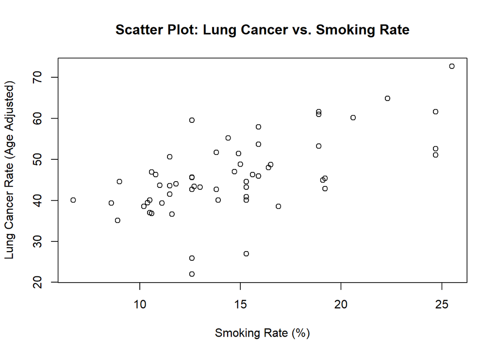

```r
plot(merged_data$Smoking_Rate,
     merged_data$Age_Adjusted_Rate,
     xlab = "Smoking Rate (%)",
     ylab = "Lung Cancer Rate (Age Adjusted)",
     main = "Scatter Plot: Lung Cancer vs. Smoking Rate")
```

```r
cor(merged_data$Smoking_Rate, merged_data$Age_Adjusted_Rate)
```

```
## [1] 0.6221573
```

A scatter plot of Age_Adjusted_Rate (Y) versus Smoking_Rate (X) shows an upward trend, and the correlation is approximately 0.62, indicating a moderately strong positive relationship.

#### Question2: Fit a simple linear regression model: Y = beta0 + beta1*X + error in R to this dataset, where you can assume that the errors are distributed independently as N(0, sigma^2).

```r
lm_model <- lm(Age_Adjusted_Rate ~ Smoking_Rate, data = merged_data)
```

#### Question3:Provide the estimates of the intercept and the slope for this dataset. What are the 95% confidence intervals for these estimates? How would you conclude if the parameters are statistically significant or not only from looking at the 95% confidence intervals?

```r
# Display a summary of the fitted model:
summary(lm_model)
```

```
##
## Call:
## lm(formula = Age_Adjusted_Rate ~ Smoking_Rate, data = merged_data)
##
## Residuals:
##      Min       1Q   Median       3Q      Max
## -21.0928  -3.4639  -0.1371   5.1453  16.5072
##
## Coefficients:
##              Estimate Std. Error t value Pr(>|t|)
## (Intercept)   26.1161     3.4429   7.586 3.73e-10 ***
## Smoking_Rate   1.3474     0.2266   5.947 1.85e-07 ***
## ---
## Signif. codes:  0 '***' 0.001 '**' 0.01 '*' 0.05 '.' 0.1 ' ' 1
##
## Residual standard error: 7.354 on 56 degrees of freedom
## Multiple R-squared:  0.3871, Adjusted R-squared:  0.3761
## F-statistic: 35.37 on 1 and 56 DF,  p-value: 1.854e-07
```

The model yields an intercept estimate of about 26.12 and a slope estimate of about 1.35.

```r
# Compute 95% confidence intervals for both coefficients
conf_intervals <- confint(lm_model, level = 0.95)
conf_intervals
```

```
##                   2.5 %    97.5 %
## (Intercept)  19.2191638 33.013042
## Smoking_Rate  0.8934968  1.801222
```

The 95% confidence interval for the intercept is roughly [19.22, 33.01], and for the slope is [0.89, 1.80]. Since neither interval includes 0, both parameters are statistically significant at the 5% level.

#### Question4: Is the impact of smoking rates on lung cancer rates in California counties statistically significant?

Yes. The slope for Smoking_Rate is positive and its 95% confidence interval does not include zero. In other words, the p-value for that coefficient is highly significant (p < 0.001), indicating that smoking rates have a statistically significant effect on lung cancer rates in California counties.

#### Question5: Find an estimate of the residual variance sigma^2. Is it also possible to find a 95% confidence interval of this residual variance from your R function?

```r
# Residual standard error (estimate of sigma)
sigma_hat <- summary(lm_model)$sigma

# Residual variance (sigma^2)
sigma_sq_hat <- sigma_hat^2
sigma_sq_hat
```

```
## [1] 54.078
```

The residual variance sigma^2 is 54.078.

The built-in summary function does not return a 95% confidence interval for the residual variance. They only give regression coefficients, not for the residual variance.